# Beyond binary choice: multinomial, conditional, and ordered models

Chapter 16, Lecture 2

**Anchor:** Does the question concern a chooser’s characteristics, attributes of the available alternatives, or an ordered outcome?  
How does a predicted change redistribute choice probabilities?

This lecture estimates models using the original **nels_small** and **cola** datasets.  
The education examples use 1,000 students; the Cola example has 1,822 choice sets, each with three alternatives (5,466 rows).

As in the panel lecture, code is displayed with execution (`eval: true`).  
Run `lecture_16_2.R` to calculate results and save figures.

## Outcomes and preparation

After this lecture you can (1) derive multinomial and conditional logit probabilities from a random-utility model and state what is identified, (2) derive every probability derivative in these models from one matrix, $\operatorname{diag}(\mathbf p)-\mathbf p\mathbf p'$, (3) state IIA as a mathematical property, show its implication of proportional substitution, and explain when it is implausible, (4) compute a consumer-surplus change from the log-sum, and (5) derive ordered-probit probabilities and marginal effects and state the restriction the ordering imposes.

**Before class:** read §§16.3–16.5 and work through the collapsed *Derivation* boxes under results R1–R8.  
In class we state and use the results.  
Appendices A–C (estimation checks, nested logit, likelihoods) are reference material beyond the textbook.

## 0 · Retrieval and connection

**Ask:** In Lecture 1, increasing Coke’s relative price reduced its probability of being purchased.  
If 7-Up is also available, where does the lost Coke probability go?  
And how does the binary logit $\Lambda(\eta)$ look if we write it with one utility index per alternative?

**Expected answer**

**Expected answer:** To Pepsi, 7-Up, or both.
If choices are exhaustive, $p_{i1}+p_{i2}+p_{i3}=1$, so the class must inspect the whole vector of predicted probabilities.
With indices $V_0,V_1$,
$$\Lambda(V_1-V_0)=\frac{1}{1+e^{-(V_1-V_0)}}=\frac{e^{V_1}}{e^{V_0}+e^{V_1}} .$$
Today’s models are this formula with $J>2$ terms in the denominator.
Everything from Lecture 1 about identification, index-scale coefficients and nonlinear derivatives carries over.

## 1 · Hook

Two investigations: (a) Do a student’s grades predict no college, two-year college or four-year college? (b) If a store raises Pepsi’s price by 10 cents, which drinks gain probability, and in what proportions?  
Ask students to identify whether `GRADES` describes a person or an alternative, and whether each drink’s price describes a person or an alternative.  
Ask whether education outcomes admit a defensible ordering.  
Record answers before introducing the models.

## 2 · Theory

Notation: person $i$ faces alternatives $j=1,\dots,J$ with deterministic utility index $V_{ij}$ and choice indicators $y_{ij}\in\{0,1\}$, $\sum_j y_{ij}=1$.

### R1 · Random utility gives the softmax; only differences are identified

Let $U_{ij}=V_{ij}+\varepsilon_{ij}$ with $\varepsilon_{ij}$ independent standard Gumbel (type-I extreme value), and let $i$ choose the alternative with the highest utility.  
Then

$$p_{ij}=P\big(U_{ij}>U_{im}\ \forall m\ne j\big)=\frac{\exp(V_{ij})}{\sum_{m=1}^J\exp(V_{im})},\qquad \sum_j p_{ij}=1 .$$

**Location.** Adding the same constant $c_i$ to every $V_{ij}$ leaves all $p_{ij}$ unchanged.  
Two consequences follow.

- *Multinomial logit (§16.3).* A person characteristic such as `GRADES` has the same value for every alternative.
  With a common coefficient it would cancel.
  It must therefore have **alternative-specific coefficients**, one set normalized to zero:
  $$V_{i,\text{none}}=0,\quad V_{i,2}=\alpha_2+\beta_2\,\text{GRADES}_i,\quad V_{i,4}=\alpha_4+\beta_4\,\text{GRADES}_i .$$
- *Conditional logit (§16.4).* An alternative attribute such as `PRICE` varies across alternatives, so one common coefficient is identified from price *differences*.
  Alternative-specific constants still need one normalization:
  $$V_{ij}=\alpha_j+\beta_P\,\text{PRICE}_{ij},\qquad \alpha_{\text{Coke}}=0 .$$

**Scale.** As in Lecture 1, the Gumbel variance $\pi^2/6$ is a normalization: only $\boldsymbol\beta/\sigma$ is identified.  
The stable `softmax()` in the code subtracts $\max_j V_{ij}$ before exponentiating.  
That is legitimate *precisely because* of location invariance.

**Derivation R1: the J-alternative Gumbel integral**

The standard Gumbel has CDF $G(\varepsilon)=\exp(-e^{-\varepsilon})$ and density $g(\varepsilon)=e^{-\varepsilon}G(\varepsilon)$.  
Condition on $\varepsilon_{ij}=\varepsilon$.  
Alternative $j$ wins if $\varepsilon_{im}<V_{ij}-V_{im}+\varepsilon$ for all $m\ne j$, so

$$p_{ij}=\int_{-\infty}^{\infty}g(\varepsilon)\prod_{m\ne j}G(V_{ij}-V_{im}+\varepsilon)\,d\varepsilon
=\int_{-\infty}^{\infty}e^{-\varepsilon}\exp\!\Big(-e^{-\varepsilon}\sum_{m=1}^J e^{V_{im}-V_{ij}}\Big)d\varepsilon ,$$

where the $m=j$ term (equal to $e^0=1$) comes from $g$.  
Substitute $t=e^{-\varepsilon}$ and write $S_j=\sum_m e^{V_{im}-V_{ij}}$:

$$p_{ij}=\int_0^\infty e^{-tS_j}\,dt=\frac{1}{S_j}=\frac{e^{V_{ij}}}{\sum_m e^{V_{im}}} .$$

For $J=2$ this is Lecture 1’s Appendix C.  
Location invariance: multiply numerator and denominator by $e^{c_i}$.

### R2 · One function generates every derivative: the log-sum

Define the **log-sum** (inclusive value) $L(\mathbf V_i)=\ln\sum_{m}e^{V_{im}}$.  
Then

$$\frac{\partial L}{\partial V_{ij}}=p_{ij},
\qquad
\frac{\partial p_{ij}}{\partial V_{ik}}=p_{ij}(\delta_{jk}-p_{ik}),
\qquad\text{i.e.}\qquad
\frac{\partial\mathbf p_i}{\partial\mathbf V_i'}=\nabla^2L=\operatorname{diag}(\mathbf p_i)-\mathbf p_i\mathbf p_i' \equiv \boldsymbol\Sigma_i .$$

$\boldsymbol\Sigma_i$ is the **covariance matrix of the choice-indicator vector** $\mathbf y_i$, the $J$-dimensional version of $p(1-p)$ from Lecture 1.  
It is symmetric and positive semidefinite, and its rows sum to zero.  
Its rank is $J-1$ with null vector $\mathbf 1$: raising every utility equally changes nothing (location invariance, R1).  
The zero row sums give the **probability budget**: every derivative vector sums to zero.

Every derivative below is $\boldsymbol\Sigma_i$ multiplied by how the indices move, $\partial\mathbf V_i/\partial x$.  
And, as R7 shows, $L$ itself is expected maximum utility.

**Derivation R2**

$\partial L/\partial V_{ij}=e^{V_{ij}}/\sum_m e^{V_{im}}=p_{ij}$.  
By the quotient rule, $\partial p_{ij}/\partial V_{ik}=\delta_{jk}p_{ij}-p_{ij}p_{ik}$.  
For the indicator vector, $E(y_{ij})=p_{ij}$, $E(y_{ij}^2)=p_{ij}$ and $E(y_{ij}y_{ik})=0$ for $j\ne k$ (only one alternative is chosen), so $\operatorname{Cov}(\mathbf y_i)=\operatorname{diag}(\mathbf p_i)-\mathbf p_i\mathbf p_i'$.  
Finally $\boldsymbol\Sigma_i\mathbf 1=\mathbf p_i-\mathbf p_i(\mathbf p_i'\mathbf 1)=\mathbf 0$.

### R3 · Probability ratios are linear in the index

For any pair of alternatives,

$$\ln\frac{p_{ij}}{p_{ik}}=V_{ij}-V_{ik}.$$

In the education MNL, $\ln(p_2/p_{\text{none}})=\alpha_2+\beta_2\,\text{GRADES}$ (textbook 16.21–16.22).  
The normalization is arbitrary; *every* pairwise contrast is identified.  
For example, $\ln(p_2/p_4)=(\alpha_2-\alpha_4)+(\beta_2-\beta_4)\,\text{GRADES}$, and $\beta_2-\beta_4$ is calculated from the two fitted slopes.  
With $J$ alternatives there are $J(J-1)/2$ pairwise contrasts but only $J-1$ free coefficient vectors.

### R4 · Multinomial-logit marginal effects: a covariance, and a sign rule

With $\partial V_{ij}/\partial x_i=\beta_j$, R2 gives textbook (16.20):

$$\frac{\partial\mathbf p_i}{\partial x_i}=\boldsymbol\Sigma_i\boldsymbol\beta
\quad\Longleftrightarrow\quad
\frac{\partial p_{ij}}{\partial x_i}=p_{ij}\big(\beta_j-\bar\beta_i\big),\qquad \bar\beta_i=\sum_m p_{im}\beta_m .$$

$\bar\beta_i$ is a probability-weighted average of the coefficients, so it always lies between $\min_m\beta_m$ and $\max_m\beta_m$.  
Hence:

- The alternative with the **largest** coefficient always has a positive marginal effect, and the one with the **smallest** always has a negative one.
- **Intermediate** alternatives change sign where $\bar\beta_i(x)=\beta_j$.  
  The coefficient sign alone does not determine the direction.

The textbook education estimates have $\beta_4<\beta_2<\beta_{\text{none}}=0$; inspect this ordering in the re-estimated model.  
So worse grades always raise the no-college probability and always lower the four-year probability.  
The two-year response changes sign at the grade where $\bar\beta_i=\beta_2$, which is also where $p_{i2}$ peaks.  
The lab finds it.

### R5 · Conditional-logit price effects and elasticities

With $\partial V_{ij}/\partial\text{PRICE}_{ik}=\beta_P\delta_{jk}$, R2 gives the full $J\times J$ Jacobian (textbook 16.24–16.25):

$$\frac{\partial\mathbf p_i}{\partial\,\textbf{price}_i'}=\beta_P\,\boldsymbol\Sigma_i:
\qquad
\frac{\partial p_{ij}}{\partial\text{PRICE}_{ij}}=\beta_P\,p_{ij}(1-p_{ij}),\qquad
\frac{\partial p_{ij}}{\partial\text{PRICE}_{ik}}=-\beta_P\,p_{ij}p_{ik}\ (k\ne j).$$

The matrix is symmetric: the effect of Coke’s price on Pepsi equals the effect of Pepsi’s price on Coke.  
Multiplying by $\text{PRICE}_{ik}/p_{ij}$ gives elasticities:

$$\epsilon_{jj}=\beta_P\,\text{PRICE}_{ij}\,(1-p_{ij}),\qquad
\epsilon_{jk}=-\beta_P\,\text{PRICE}_{ik}\,p_{ik}\quad(k\ne j).$$

The cross-elasticity $\epsilon_{jk}$ **does not depend on $j$**: a change in $k$’s price moves every other alternative’s probability by the same percentage.  
Each column of the elasticity matrix is constant off the diagonal.  
This is IIA expressed in elasticities.

### R6 · IIA and proportional substitution

From R3, $p_{ij}/p_{ik}=\exp(V_{ij}-V_{ik})$ does not involve any third alternative.  
For a *finite* change in $V_{ik}$ alone, with $S=\sum_m e^{V_{im}}$,

$$\frac{p_{ij}^{\text{new}}}{p_{ij}^{\text{old}}}=\frac{S^{\text{old}}}{S^{\text{new}}}\quad\text{for every }j\ne k .$$

This is exact, not just a local approximation.  
The lost (or gained) probability is redistributed **in proportion to existing shares**, whatever the alternatives are like.

**Red bus / blue bus.** Car and red bus have equal utility, so $p=(\tfrac12,\tfrac12)$.  
Add a blue bus identical to the red one.  
Logit predicts $(\tfrac13,\tfrac13,\tfrac13)$, so car loses a third of its share to a bus that differs only in colour.  
Behaviour closer to $(\tfrac12,\tfrac14,\tfrac14)$ is expected.  
IIA is a restriction, not a finding.  
It is implausible when alternatives are close substitutes.  
Nested logit (Appendix B), mixed logit and multinomial probit relax it.  
The Hausman–McFadden test re-estimates on a reduced choice set and compares the estimates (§16.3.3).

**Derivation R6**

For $j\ne k$, $p_{ij}^{\text{new}}/p_{ij}^{\text{old}}=(e^{V_{ij}}/S^{\text{new}})/(e^{V_{ij}}/S^{\text{old}})=S^{\text{old}}/S^{\text{new}}$, the same for every $j\ne k$.  
In derivatives: $(\partial p_{ij}/\partial V_{ik})/p_{ij}=-p_{ik}$, independent of $j$, which is the elasticity statement in R5.  
For the buses, with all $V=0$, $p=1/J$ for each alternative.

### R7 · The log-sum is expected maximum utility, so it measures welfare

The maximum of independent Gumbels with locations $V_{ij}$ is Gumbel with location $L(\mathbf V_i)$, so

$$E\big[\max_j U_{ij}\big]=\ln\sum_j e^{V_{ij}}+\gamma,\qquad\gamma\approx0.5772 .$$

If utility is linear in price with coefficient $\beta_P=-\alpha$, then $\alpha$ is the marginal utility of money, and the expected consumer-surplus change from a price change is

$$\Delta CS_i=\frac{L(\mathbf V_i^{\text{new}})-L(\mathbf V_i^{\text{old}})}{\alpha},
\qquad
\frac{\partial CS_i}{\partial\text{PRICE}_{ij}}=-p_{ij} .$$

The derivative is a Roy’s-identity analogue: the welfare loss per unit of a price increase equals the expected quantity of that product purchased.  
This assumes no income effects (constant $\alpha$).

**Derivation R7**

$P(\max_j U_{ij}\le u)=\prod_j\exp(-e^{-(u-V_{ij})})=\exp\big(-e^{-u}\sum_j e^{V_{ij}}\big)=\exp\big(-e^{-(u-L)}\big)$, a Gumbel CDF with location $L$.  
A standard Gumbel has mean $\gamma$, hence $E\max=L+\gamma$.  
Dividing utility by $\alpha$ converts it to money.  
By R2, $\partial L/\partial\text{PRICE}_{ij}=p_{ij}\beta_P=-\alpha p_{ij}$, so $\partial CS/\partial\text{PRICE}_{ij}=-p_{ij}$.

### R8 · Ordered probit: two thresholds on one index

Let $y_i^*=\beta x_i+e_i$ with $e_i\sim N(0,1)$, and $Y=1$ (no college) if $y^*\le\mu_1$, $Y=2$ (two-year) if $\mu_1<y^*\le\mu_2$, $Y=3$ (four-year) if $y^*>\mu_2$.  
Then

$$P(Y\le k\mid x)=\Phi(\mu_k-\beta x),\quad
P(Y=1)=\Phi(\mu_1-\beta x),\quad
P(Y=2)=\Phi(\mu_2-\beta x)-\Phi(\mu_1-\beta x),\quad
P(Y=3)=1-\Phi(\mu_2-\beta x).$$

**Identification.** There is no intercept, because it would be collinear with the thresholds: only $\mu_k-\beta_0$ is identified.  
The error variance is normalized to one, as in Lecture 1.

**Marginal effects** (textbook §16.5.2):

$$\frac{\partial P(Y=1)}{\partial x}=-\beta\,\phi(\mu_1-\beta x),\quad
\frac{\partial P(Y=2)}{\partial x}=\beta\big[\phi(\mu_1-\beta x)-\phi(\mu_2-\beta x)\big],\quad
\frac{\partial P(Y=3)}{\partial x}=\beta\,\phi(\mu_2-\beta x).$$

**The middle category peaks where the two densities are equal.** Since $\phi$ is symmetric, $\phi(\mu_1-\beta x)=\phi(\mu_2-\beta x)$ iff $\mu_1-\beta x=-(\mu_2-\beta x)$, i.e.

$$x^*=\frac{\mu_1+\mu_2}{2\beta}.$$

The middle probability rises on one side of $x^*$ and falls on the other.  
Its response “need not keep one sign” for a precise reason.

**What the ordering imposes.** Every cumulative probability depends on $x$ through the *same* index $\beta x$.  
Two consequences follow.

- 1. A change in $x$ moves all $P(Y\le k\mid x)$ in the same direction, so the whole outcome distribution shifts in the sense of first-order stochastic dominance.
- 2. $\Phi^{-1}\{P(Y\le k\mid x)\}=\mu_k-\beta x$ is linear in $x$ with the **same slope** $-\beta$ for every $k$ (the “parallel regression” restriction; in ordered logit, proportional odds).

MNL imposes neither.  
That is the substantive trade-off: 3 parameters instead of 4, bought with a single-index restriction.  
The chapter’s displayed equation (16.26) reverses category wording relative to the surrounding exposition.  
**This lecture consistently uses** `1 = no college`, `2 = two-year`, `3 = four-year`, as in the data and estimates.

**Derivation R8**

$P(Y\le k)=P(\beta x+e\le\mu_k)=P(e\le\mu_k-\beta x)=\Phi(\mu_k-\beta x)$.  
Category probabilities are differences of adjacent cumulative probabilities.  
Differentiate with the chain rule, using $\Phi'=\phi$ and $\partial(\mu_k-\beta x)/\partial x=-\beta$.  
The three marginal effects sum to zero (the probability budget again).  
For the peak: $\phi(a)=\phi(b)$ with $a\ne b$ requires $a=-b$, i.e. $\mu_1+\mu_2=2\beta x$.  
The second derivative confirms a maximum of $P(Y=2)$ at $x^*$ whenever $\mu_1<\mu_2$.

### Standard probability elasticity · From a slope to a percentage response

For a continuous positive $x$ and category probability $p_j(x)>0$,

$$\epsilon_j(x)=\frac{\partial p_j}{\partial x}\frac{x}{p_j}
=\frac{\partial\ln p_j}{\partial\ln x}.$$

A small 1% increase in $x$ changes $p_j$ by approximately $\epsilon_j$ **percent of its starting value**.  
It does not change probability by $\epsilon_j$ percentage points.  
For example, $p_j=0.20$ and $\epsilon_j=-0.5$ imply $\Delta p_j\approx-0.001$, or −0.1 percentage points.

| Model | Elasticity |
| --- | --- |
| Education MNL | $\epsilon_{ij}=x_i(\beta_j-\sum_m p_{im}\beta_m)$ |
| Conditional logit, own price | $\epsilon_{ij,j}=\beta_P P_{ij}(1-p_{ij})$ |
| Conditional logit, another price | $\epsilon_{ij,k}=-\beta_P P_{ik}p_{ik}$ for $j\ne k$ |
| Ordered probit, category $j$ | $\epsilon_{ij}=\dfrac{x_i\beta[\phi(\mu_{j-1}-\beta x_i)-\phi(\mu_j-\beta x_i)]}{p_{ij}}$ |

For ordered probit, $\mu_0=-\infty$, $\mu_J=\infty$, and the density at either infinite endpoint is zero.  
The average elasticity is $N^{-1}\sum_i\epsilon_{ij}$; it is generally not the elasticity evaluated at average covariates.  
Probability slopes sum to zero, but elasticities do not generally sum to zero: instead $\sum_j p_{ij}\epsilon_{ij}=0$ for a common change in $x_i$.

`marginaleffects::slopes(..., slope = "eyex")` implements this scaling for supported models, including `multinom` and `polr`.  
For `mlogit` objects, use predictions with a custom contrast, as demonstrated below.  
Do not take a point elasticity of a binary feature/display indicator.  
The percentage interpretation for the grade index is coding-dependent, unlike a price ratio or money amount.

References: [Elasticity](https://marginaleffects.com/bonus/elasticity.html) and [mlogit predictions and custom contrasts](https://marginaleffects.com/bonus/mlogit.html).

## 3 · Live econometric lab

### Setup · Load the original data and estimate the models

```r
library(mlogit)
library(nnet)
library(marginaleffects)

# Definitions:
# https://www.principlesofeconometrics.com/poe5/data/def/nels_small.def
# https://www.principlesofeconometrics.com/poe5/data/def/cola.def
load(url("https://www.principlesofeconometrics.com/poe5/data/rdata/nels_small.rdata"))
load(url("https://www.principlesofeconometrics.com/poe5/data/rdata/cola.rdata"))
head(nels_small)
```

```
  psechoice hscath grades faminc famsiz parcoll female black
1         2      0   9.08   62.5      5       0      0     0
2         2      0   8.31   42.5      4       0      1     0
3         3      0   7.42   62.5      4       0      1     0
4         3      0   7.42   62.5      4       0      1     0
5         3      0   7.42   62.5      4       0      1     0
6         3      0   7.46   12.5      2       0      1     0
```

```r
head(cola)
```

```
  id choice price feature display
1  1      0  1.79       0       0
2  1      0  1.79       0       0
3  1      1  1.79       0       0
4  2      0  1.79       0       0
5  2      0  1.79       0       0
6  2      1  0.89       1       1
```

```r
names_education <- c("No college", "Two-year", "Four-year")
nels_small$education <- factor(nels_small$psechoice, levels = 1:3,
                               labels = names_education)
nels_small$education_ordered <- ordered(nels_small$education,
                                        levels = names_education)
# Larger grades means WORSE performance. No college is the reference.
# multinom estimates the same MNL as mlogit(education ~ 0 | grades).
# This fitted class supports marginaleffects::slopes() directly.
mnl <- nnet::multinom(education ~ grades, data = nels_small,
                      trace = FALSE, Hess = TRUE, maxit = 1000,
                      reltol = 1e-10)
summary(mnl)
```

```
Call:
nnet::multinom(formula = education ~ grades, data = nels_small,
    Hess = TRUE, trace = FALSE, maxit = 1000, reltol = 1e-10)

Coefficients:
          (Intercept)     grades
Two-year     2.506420 -0.3087887
Four-year    5.769876 -0.7061967

Std. Errors:
          (Intercept)     grades
Two-year    0.4183848 0.05228487
Four-year   0.4043229 0.05292459

Residual Deviance: 1750.626
AIC: 1758.626
```

```r
prop.table(table(nels_small$education))
```

```
No college   Two-year  Four-year
     0.222      0.251      0.527
```

```r
colMeans(fitted(mnl))
```

```
No college   Two-year  Four-year
     0.222      0.251      0.527
```

```r
# Cola records are in Pepsi, 7-Up, Coke order WITHIN each original id.
# Assign brand labels BEFORE any sorting; id identifies a complete choice set.
names_drinks <- c("Pepsi", "7-Up", "Coke")
cola$brand <- factor(rep(names_drinks, times = nrow(cola) / 3),
                     levels = names_drinks)
stopifnot(all(table(cola$id) == 3),
          all(tapply(cola$choice, cola$id, sum) == 1))
cola_long <- mlogit.data(cola, choice = "choice", shape = "long",
                         chid.var = "id", alt.var = "brand")
cl <- mlogit(choice ~ price | 1, data = cola_long, reflevel = "Coke")
summary(cl)
```

```
Call:
mlogit(formula = choice ~ price | 1, data = cola_long, reflevel = "Coke",
    method = "nr")

Frequencies of alternatives:choice
   Coke   Pepsi    7-Up
0.27991 0.34577 0.37431

nr method
4 iterations, 0h:0m:0s
g'(-H)^-1g = 0.00222
successive function values within tolerance limits

Coefficients :
                   Estimate Std. Error  z-value  Pr(>|z|)
(Intercept):Pepsi  0.283165   0.062381   4.5393 5.644e-06 ***
(Intercept):7-Up   0.103833   0.062470   1.6621   0.09649 .
price             -2.296363   0.137658 -16.6817 < 2.2e-16 ***
---
Signif. codes:  0 '***' 0.001 '**' 0.01 '*' 0.05 '.' 0.1 ' ' 1

Log-Likelihood: -1824.6
McFadden R^2:  0.082484
Likelihood ratio test : chisq = 328.05 (p.value = < 2.22e-16)
```

```r
# The price-only specification matches the main textbook example.
# feature and display are retained in cola for an optional extension.

# Stable softmax and log-sum; all coefficients below come from fitted models.
softmax <- function(v) {
  w <- exp(v - max(v))
  w / sum(w)
}
logsum <- function(v) max(v) + log(sum(exp(v - max(v))))
B <- coef(mnl)
alpha_edu <- c(0, B["Two-year", "(Intercept)"], B["Four-year", "(Intercept)"])
beta_edu <- c(0, B["Two-year", "grades"], B["Four-year", "grades"])
education_prob <- function(grades) {
  setNames(softmax(alpha_edu + beta_edu * grades), names_education)
}
education_me <- function(grades) {
  p <- education_prob(grades)
  p * (beta_edu - sum(p * beta_edu))
}
b_cl <- coef(cl)
alpha_drink <- c(unname(b_cl["(Intercept):Pepsi"]),
                 unname(b_cl["(Intercept):7-Up"]), 0)
beta_price <- unname(b_cl["price"])
stopifnot(!anyNA(c(alpha_drink, beta_price)))
drink_index <- function(prices) alpha_drink + beta_price * prices
drink_prob <- function(prices) {
  setNames(softmax(drink_index(prices)), names_drinks)
}
```

### Step 0 · The results, by hand

**Question:** Do R1–R3 hold numerically?  
**Prediction:** shifting all indices changes nothing, and scaling them does.  
The gradient of the log-sum is the probability vector, and its Hessian has zero row sums.  
**Action:**

```r
v <- alpha_edu + beta_edu * 6.64
rbind(original = softmax(v),               # R1: location invariance
      shifted  = softmax(v + 7),
      scaled   = softmax(2 * v))           # scale is NOT innocuous: beta/sigma
```

```
               [,1]      [,2]      [,3]
original 0.18100603 0.2856002 0.5333938
shifted  0.18100603 0.2856002 0.5333938
scaled   0.08214627 0.2045120 0.7133417
```

```r
h <- 1e-6                                  # R2: numerical gradient and Hessian
grad_L <- sapply(1:3, function(j) (logsum(v + h * (1:3 == j)) - logsum(v)) / h)
p <- softmax(v)
Sigma <- diag(p) - p %*% t(p)
list(gradient_vs_p = rbind(grad_L, p), Sigma = Sigma, row_sums = rowSums(Sigma))
```

```
$gradient_vs_p
            [,1]      [,2]      [,3]
grad_L 0.1810061 0.2856003 0.5333939
p      0.1810060 0.2856002 0.5333938

$Sigma
            [,1]        [,2]        [,3]
[1,]  0.14824285 -0.05169536 -0.09654749
[2,] -0.05169536  0.20403272 -0.15233737
[3,] -0.09654749 -0.15233737  0.24888486

$row_sums
[1] 1.387779e-17 1.387779e-17 0.000000e+00
```

```r
c(two_vs_none = beta_edu[2], four_vs_none = beta_edu[3],   # R3: every pair
  two_vs_four = beta_edu[2] - beta_edu[3])
```

```
 two_vs_none four_vs_none  two_vs_four
  -0.3087887   -0.7061967    0.3974080
```

```r
exp(beta_edu[2] - beta_edu[3])   # odds of two-year vs four-year, per GRADES unit
```

```
[1] 1.487963
```

**Interpretation/decision:** The shifted row equals the original; the scaled row does not. `Sigma` is the matrix that produces every derivative in R4 and R5.  
Its zero row sums are the probability budget.  
State the contrast in words: one unit worse `GRADES` multiplies the two-year-to-four-year odds by $\exp(\hat\beta_2-\hat\beta_4)$, whatever the grade level.

### Step 1 · Education probabilities and marginal effects

**Question:** What happens to each outcome as `GRADES` rises (worse performance)?  
**Prediction:** by R4, no college always rises, four-year always falls, and two-year first rises then falls.  
**R action:** calculate two profiles, the R4 marginal effects, and the sign-change point, and plot a full range.

```r
education_prob(2.635)  # better grades
```

```
No college   Two-year  Four-year
0.01776644 0.09655111 0.88568245
```

```r
education_prob(6.64)   # median grades
```

```
No college   Two-year  Four-year
 0.1810060  0.2856002  0.5333938
```

```r
rbind(`ME at 2.635` = education_me(2.635), `ME at 6.64` = education_me(6.64))
```

```
            No college   Two-year  Four-year
ME at 2.635 0.01164199 0.03345411 -0.0450961
ME at 6.64  0.08414446 0.04457714 -0.1287216
```

```r
g_star <- optimize(function(x) education_prob(x)[2],
                   interval = range(nels_small$grades), maximum = TRUE)$maximum
# An interior maximum has a zero slope; a boundary maximum need not.
c(g_star = g_star, education_prob(g_star))
```

```
    g_star No college   Two-year  Four-year
 8.5276361  0.3762375  0.3314253  0.2923372
```

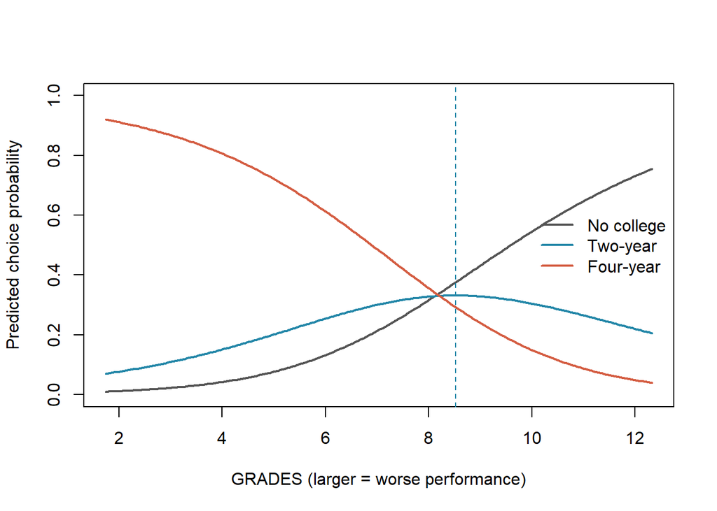

```r
g <- seq(min(nels_small$grades), max(nels_small$grades), length.out = 200)
edu_matrix <- t(vapply(g, education_prob, numeric(3)))
matplot(g, edu_matrix, type = "l", lty = 1, lwd = 2,
        col = c("#555555", "#2487a8", "#d45d42"), ylim = c(0, 1),
        xlab = "GRADES (larger = worse performance)",
        ylab = "Predicted choice probability")
abline(v = g_star, lty = 2, col = "#2487a8")
legend("right", names_education, lty = 1, lwd = 2,
       col = c("#555555", "#2487a8", "#d45d42"), bty = "n")
```

**Result/interpretation:** Inspect the estimated probabilities and marginal effects at both grade profiles.  
The dashed line marks the largest fitted two-year probability within the observed grade range. `grades` is inversely coded: larger means worse.  
**Decision:** report effects on all categories.  
These conditional associations do not by themselves show the effect of improving grades.

#### Education elasticities

The output reports one elasticity for each education outcome at each grade profile.  
Compare the software estimates with the MNL formula above.

```r
grade_profiles <- data.frame(grades = c(2.635, 6.64))
slopes(mnl, variables = "grades", newdata = grade_profiles, slope = "eyex")
```

```
      Group Estimate Std. Error     z Pr(>|z|)     S  2.5 % 97.5 %
 No college    1.727      0.146  11.9   <0.001 105.2  1.441  2.012
 No college    3.087      0.296  10.4   <0.001  82.3  2.507  3.666
 Two-year      0.913      0.116   7.9   <0.001  48.3  0.686  1.140
 Two-year      1.036      0.182   5.7   <0.001  26.4  0.680  1.392
 Four-year    -0.134      0.011 -12.2   <0.001 110.9 -0.156 -0.113
 Four-year    -1.602      0.133 -12.1   <0.001 109.0 -1.863 -1.342

Term: grades
Type: probs
Comparison: eY/eX
```

```r
avg_slopes(mnl, variables = "grades", slope = "eyex")
```

```
      Group Estimate Std. Error      z Pr(>|z|)     S  2.5 % 97.5 %
 No college     2.61      0.225  11.60  < 0.001 101.0  2.166  3.047
 Two-year       0.59      0.187   3.16  0.00158   9.3  0.224  0.956
 Four-year     -2.01      0.168 -11.92  < 0.001 106.5 -2.335 -1.676

Term: grades
Type: probs
Comparison: eY/eX
```

```r
rbind(at_2.635 = education_me(2.635) * 2.635 / education_prob(2.635),
      at_6.64 = education_me(6.64) * 6.64 / education_prob(6.64))
```

```
         No college  Two-year  Four-year
at_2.635   1.726663 0.9130043 -0.1341657
at_6.64    3.086744 1.0363866 -1.6024024
```

### Step 2 · Probability budget

**Question:** If four-year college loses probability, must each other category gain?  
**Prediction:** their combined gain must offset the loss; separate signs depend on the model and profile (R4).  
**Action:**

```r
change <- education_prob(6.64) - education_prob(2.635)
change
```

```
No college   Two-year  Four-year
 0.1632396  0.1890491 -0.3522887
```

```r
sum(change)              # zero up to floating point error: finite changes
```

```
[1] 5.551115e-17
```

```r
sum(education_me(6.64))  # zero: derivatives (rows of Sigma sum to zero)
```

```
[1] -4.857226e-17
```

**Result/decision:** In this comparison both no college and two-year gain.  
That particular split is a result.  
The zero sum is an accounting identity for exhaustive choices, and in derivative form it is $\mathbf 1'\boldsymbol\Sigma_i=\mathbf 0'$.  
Had the comparison run from 6.64 to 11, two-year would have *lost*.

### Step 3 · Own-price change, the Jacobian and elasticities

**Question:** If only Pepsi rises by 10 cents, which drink probabilities change?  
**Prediction:** Pepsi falls; the other two rise (R5).  
**Action:** compute the finite change, the full derivative matrix $\beta_P\boldsymbol\Sigma$ and the elasticity matrix.

```r
base_prices <- c(Pepsi = 1.00, `7-Up` = 1.25, Coke = 1.10)
pepsi_up <- base_prices
pepsi_up["Pepsi"] <- 1.10
drink_table <- rbind(Baseline = drink_prob(base_prices),
                     `Pepsi +10 cents` = drink_prob(pepsi_up))
round(drink_table, 4)
```

```
                 Pepsi   7-Up   Coke
Baseline        0.4832 0.2275 0.2893
Pepsi +10 cents 0.4263 0.2525 0.3212
```

```r
round(drink_table[2, ] - drink_table[1, ], 4)
```

```
  Pepsi    7-Up    Coke
-0.0569  0.0250  0.0318
```

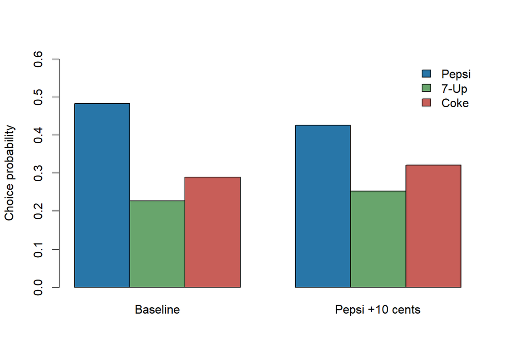

```r
barplot(t(drink_table), beside = TRUE, ylim = c(0, 0.6),
        col = c("#2876a8", "#68a56c", "#c85e58"),
        ylab = "Choice probability", legend.text = names_drinks,
        args.legend = list(x = "topright", bty = "n"))
```

```r
p0 <- drink_prob(base_prices)
jacobian <- beta_price * (diag(p0) - p0 %*% t(p0))           # R5
dimnames(jacobian) <- list(prob = names_drinks, price = names_drinks)
round(jacobian, 4)       # first row reproduces Table 16.4b
```

```
       price
prob      Pepsi    7-Up    Coke
  Pepsi -0.5734  0.2524  0.3211
  7-Up   0.2524 -0.4035  0.1511
  Coke   0.3211  0.1511 -0.4722
```

```r
elasticity <- jacobian * outer(1 / p0, base_prices)          # dp_j/dP_k * P_k/p_j
round(elasticity, 3)     # off-diagonal columns are constant: IIA
```

```
       price
prob     Pepsi   7-Up   Coke
  Pepsi -1.187  0.653  0.731
  7-Up   1.110 -2.218  0.731
  Coke   1.110  0.653 -1.795
```

**Result/decision:** Read the baseline and changed Pepsi probabilities from `drink_table`.  
Multiply the Pepsi own-price derivative by 0.10 for the tangent approximation.  
The Jacobian is symmetric, and in the elasticity matrix each column has identical off-diagonal entries.  
State the own-price change and which other prices remain fixed.  
This is a model prediction, not evidence from an actual randomised price change.

#### Cola elasticity using `marginaleffects`

Change **only Pepsi’s price**, holding the other alternatives fixed.  
The custom contrast estimates

$$\epsilon_{j,\mathrm{Pepsi}}\approx
\frac{\ln p_j(P_{\mathrm{Pepsi}}e^h)-\ln p_j(P_{\mathrm{Pepsi}}e^{-h})}{2h}.$$

The three results are Pepsi’s own-price elasticity and the two cross-price elasticities, with delta-method uncertainty.  
At this common profile, compare them with the exact matrix above.

```r
# A symmetric log-price perturbation estimates d log(p_j) / d log(P_Pepsi).
# id1/id2 are the choice-set and alternative indices expected by the
# marginaleffects mlogit adapter (see the linked package vignette).
h_log <- 1e-4
nd <- as.data.frame(cola_long)
idx <- dfidx::idx(cola_long)
nd$id1 <- idx[[1]]
nd$id2 <- idx[[2]]
nd$idx <- NULL
# Give every shopper the same stated price profile for this comparison.
nd$price <- unname(base_prices[as.character(nd$id2)])
# The marginaleffects mlogit adapter reads rows in the model's internal
# alternative order (reference level first: Coke, Pepsi, 7-Up), not by id2.
# Without this sort, prices are silently attached to the wrong brands.
alt_order <- names(cl$freq)
nd <- nd[order(nd$id1, match(as.character(nd$id2), alt_order)), ]
# Guard: baseline predictions must reproduce drink_prob(base_prices).
base_check <- aggregate(estimate ~ group, FUN = mean,
                        data = predictions(cl, newdata = nd))
stopifnot(isTRUE(all.equal(
  base_check$estimate,
  unname(drink_prob(base_prices)[as.character(base_check$group)]),
  tolerance = 1e-6)))
lo <- transform(nd, term = "lo",
                price = ifelse(id2 == "Pepsi", price * exp(-h_log), price))
hi <- transform(nd, term = "hi",
                price = ifelse(id2 == "Pepsi", price * exp(h_log), price))
scenarios <- rbind(lo, hi)
scenarios$term <- factor(scenarios$term, levels = c("lo", "hi"))

# All shoppers have the same profile here, so group means equal each
# profile probability. Explicit matching avoids depending on row order.
pepsi_elasticity <- function(x) {
  a <- aggregate(estimate ~ term + group, data = x, FUN = mean)
  low <- a[a$term == "lo", ]
  high <- a[a$term == "hi", ]
  high <- high[match(low$group, high$group), ]
  data.frame(term = as.character(low$group),
             estimate = (log(high$estimate) - log(low$estimate)) / (2 * h_log))
}
predictions(cl, newdata = scenarios, hypothesis = pepsi_elasticity)
```

```
  Term Estimate Std. Error     z Pr(>|z|)     S  2.5 % 97.5 %
 7-Up      1.11     0.0904  12.3   <0.001 112.6  0.932   1.29
 Coke      1.11     0.0904  12.3   <0.001 112.6  0.932   1.29
 Pepsi    -1.19     0.0602 -19.7   <0.001 285.1 -1.305  -1.07

Type: response
```

```r
# Compare the three estimates with the Pepsi-price column of the exact matrix.
elasticity[, "Pepsi"]
```

```
    Pepsi      7-Up      Coke
-1.186777  1.109586  1.109586
```

### Step 4 · Competitor’s price and proportional substitution

**Question:** Does raising Coke’s price have the same sign for Pepsi as raising Pepsi’s own price?  
And when Pepsi’s price rises, do 7-Up and Coke gain in proportion to their shares?  
**Prediction:** no to the first; yes to the second (R6), exactly.  
**Action:**

```r
coke_up <- base_prices
coke_up["Coke"] <- 1.25
round(drink_prob(coke_up) - drink_prob(base_prices), 4)
```

```
  Pepsi    7-Up    Coke
 0.0445  0.0209 -0.0654
```

```r
# R6: after/before ratios for a Pepsi price increase
round(drink_prob(pepsi_up) / drink_prob(base_prices), 4)
```

```
 Pepsi   7-Up   Coke
0.8823 1.1101 1.1101
```

```r
exp(logsum(drink_index(base_prices)) - logsum(drink_index(pepsi_up)))  # S_old / S_new
```

```
[1] 1.110051
```

**Result/decision:** Read Pepsi’s predicted gain from the output.  
Do not compare the one-dollar local derivative directly to this 15-cent finite change (§16.4, Example 16.13).  
In the second output, 7-Up and Coke are both multiplied by the same factor, $S^{\text{old}}/S^{\text{new}}$.  
The model cannot say that Coke is the closer substitute for Pepsi.

### Step 5 · IIA and the red-bus problem

**Question:** If only 7-Up’s price changes, does the Pepsi-to-Coke *ratio* change?  
What happens when a near-duplicate alternative appears?  
**Prediction:** the ratio does not change under this model, though both levels can.  
A duplicate steals share proportionally unless the model has nests.  
**Action:**

```r
sevenup_up <- base_prices
sevenup_up["7-Up"] <- 1.40
before <- drink_prob(base_prices)
after <- drink_prob(sevenup_up)
rbind(before = before, after = after)
```

```
           Pepsi      7-Up      Coke
before 0.4831927 0.2274640 0.2893433
after  0.5174929 0.1726243 0.3098828
```

```r
c(before_ratio = before["Pepsi"] / before["Coke"],
  after_ratio = after["Pepsi"] / after["Coke"])
```

```
before_ratio.Pepsi  after_ratio.Pepsi
          1.669964           1.669964
```

```r
# Red bus / blue bus with a nested logit (Appendix B): car alone; buses in one nest.
nested_bus <- function(lambda) {
  bus_nest <- 2^lambda                    # (e^0 + e^0)^lambda
  c(car = 1, red_bus = bus_nest / 2, blue_bus = bus_nest / 2) / (1 + bus_nest)
}
round(sapply(c(`MNL (lambda = 1)` = 1, `lambda = 0.5` = 0.5,
               `lambda = 0.01` = 0.01), nested_bus), 3)
```

```
         MNL (lambda = 1) lambda = 0.5 lambda = 0.01
car                 0.333        0.414         0.498
red_bus             0.333        0.293         0.251
blue_bus            0.333        0.293         0.251
```

**Interpretation/decision:** IIA gives the unchanged ratio *by construction*.  
Claiming this proves shoppers do not substitute is the deliberate failure: probability levels can change, and the restriction may misdescribe substitution when options are close substitutes.  
This calculation illustrates IIA; it does not test it.  
The nested model moves from $(\tfrac13,\tfrac13,\tfrac13)$ toward $(\tfrac12,\tfrac14,\tfrac14)$ as the within-nest correlation rises ($\lambda\to0$).

### Step 6 · Welfare from the log-sum

**Question:** In dollars per shopping trip, what does the 10-cent Pepsi increase cost the average shopper facing these prices?  
**Prediction:** a little under $0.10\times p_{\text{Pepsi}}\approx\$0.048$.  
The first-order approximation overstates the loss because shoppers substitute away (R7).  
**Action:**

```r
alpha_money <- -beta_price                 # marginal utility of one dollar
c(delta_CS  = (logsum(drink_index(pepsi_up)) -
               logsum(drink_index(base_prices))) / alpha_money,
  first_order = -drink_prob(base_prices)[["Pepsi"]] * 0.10)
```

```
   delta_CS first_order
-0.04546566 -0.04831927
```

**Decision:** The log-sum gives an exact expected compensating variation under the model’s assumptions, including no income effects.  
The first-order term, $-p_j\Delta\text{PRICE}_j$, is the Roy’s-identity analogue.  
Its gap to the exact value is the welfare counterpart of the tangent-versus-finite-change distinction in Lecture 1.

### Step 7 · Is the education outcome ordered?

**Question:** Does a two-threshold model yield a useful description of education progression, and where does the middle category peak?  
**Prediction:** top and bottom probabilities move in opposite directions; the middle peaks at $x^*=(\mu_1+\mu_2)/(2\beta)$ (R8).  
**Action:** estimate ordered probit on `nels_small`, plot, and check the parallel-index restriction against the MNL.

```r
op <- MASS::polr(education_ordered ~ grades, data = nels_small,
                 method = "probit", Hess = TRUE)
summary(op)
```

```
Call:
MASS::polr(formula = education_ordered ~ grades, data = nels_small,
    Hess = TRUE, method = "probit")

Coefficients:
         Value Std. Error t value
grades -0.3066    0.01917  -15.99

Intercepts:
                    Value    Std. Error t value
No college|Two-year  -2.9456   0.1468   -20.0615
Two-year|Four-year   -2.0900   0.1358   -15.3939

Residual Deviance: 1751.643
AIC: 1757.643
```

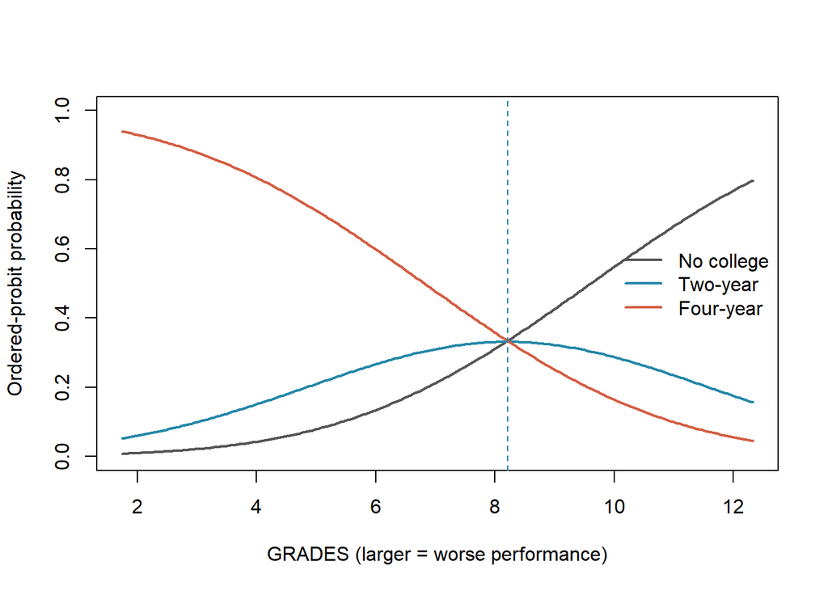

```r
beta_op <- unname(coef(op)["grades"])
mu1 <- unname(op$zeta[1]); mu2 <- unname(op$zeta[2])
ordered_prob <- function(grades) {
  low <- pnorm(mu1 - beta_op * grades)
  below_high <- pnorm(mu2 - beta_op * grades)
  setNames(c(low, below_high - low, 1 - below_high), names_education)
}
ordered_me <- function(grades) {                                   # R8
  a1 <- mu1 - beta_op * grades; a2 <- mu2 - beta_op * grades
  setNames(beta_op * c(-dnorm(a1), dnorm(a1) - dnorm(a2), dnorm(a2)),
           names_education)
}
x_star <- (mu1 + mu2) / (2 * beta_op)
ordered_matrix <- t(vapply(g, ordered_prob, numeric(3)))
matplot(g, ordered_matrix, type = "l", lty = 1, lwd = 2,
        col = c("#555555", "#2487a8", "#d45d42"), ylim = c(0, 1),
        xlab = "GRADES (larger = worse performance)",
        ylab = "Ordered-probit probability")
abline(v = x_star, lty = 2, col = "#2487a8")
legend("right", names_education, lty = 1, lwd = 2,
       col = c("#555555", "#2487a8", "#d45d42"), bty = "n")
```

```r
ordered_prob(2.635)
```

```
No college   Two-year  Four-year
0.01627273 0.08364161 0.90008566
```

```r
ordered_prob(6.64)
```

```
No college   Two-year  Four-year
 0.1815143  0.2969521  0.5215336
```

```r
rbind(`OP ME at 2.635` = ordered_me(2.635), `OP ME at 6.64` = ordered_me(6.64))
```

```
               No college   Two-year   Four-year
OP ME at 2.635 0.01245253 0.04132614 -0.05377867
OP ME at 6.64  0.08088233 0.04126548 -0.12214781
```

```r
c(x_star_ordered = x_star, g_star_mnl = g_star)
```

```
x_star_ordered     g_star_mnl
      8.211316       8.527636
```

```r
# R8 (ii): slopes of qnorm(P(Y <= k)) in GRADES. Ordered probit: -beta for both k.
cum_slope <- function(prob_fun, x, h = 1e-5) {
  cz <- function(x) { p <- prob_fun(x); qnorm(c(p[1], p[1] + p[2])) }
  setNames((cz(x + h) - cz(x)) / h, c("P(Y<=1)", "P(Y<=2)"))
}
rbind(ordered_2.635 = cum_slope(ordered_prob, 2.635),
      ordered_6.64  = cum_slope(ordered_prob, 6.64),
      mnl_2.635     = cum_slope(education_prob, 2.635),
      mnl_6.64      = cum_slope(education_prob, 6.64))
```

```
                P(Y<=1)   P(Y<=2)
ordered_2.635 0.3066259 0.3066259
ordered_6.64  0.3066259 0.3066259
mnl_2.635     0.2659342 0.2333177
mnl_6.64      0.3195534 0.3237923
```

**Decision:** Compare the estimated category effects and the locations of the two-year probability peaks.  
The ordered model forces equal, constant slopes on the probit scale.  
The MNL’s implied slopes vary with grades: they are nearly parallel near the median but clearly differ across $k$ for good students.  
Whether that difference matters is an empirical question (assess the parallel-index restriction with an appropriate ordered-probit specification test).  
The ordered model imposes a common underlying progression; the unordered multinomial model lets category-specific grade relationships differ.  
Ask whether “two-year college lies between no and four-year” is the substantive assumption the research question needs, particularly if students choose two-year college for distinct reasons.

#### Ordered-probit elasticities

```r
slopes(op, variables = "grades", newdata = grade_profiles, slope = "eyex")
```

```
      Group Estimate Std. Error      z Pr(>|z|)     S  2.5 % 97.5 %
 No college    2.016      0.193  10.45   <0.001  82.5  1.638  2.395
 No college    2.959      0.218  13.60   <0.001 137.5  2.532  3.385
 Two-year      1.302      0.146   8.89   <0.001  60.5  1.015  1.589
 Two-year      0.923      0.101   9.12   <0.001  63.6  0.724  1.121
 Four-year    -0.157      0.013 -12.10   <0.001 109.5 -0.183 -0.132
 Four-year    -1.555      0.110 -14.16   <0.001 148.9 -1.770 -1.340

Term: grades
Type: probs
Comparison: eY/eX
```

```r
avg_slopes(op, variables = "grades", slope = "eyex")
```

```
      Group Estimate Std. Error      z Pr(>|z|)     S  2.5 % 97.5 %
 No college    2.645     0.1848  14.32   <0.001 152.0  2.283  3.007
 Two-year      0.518     0.0757   6.84   <0.001  36.9  0.369  0.666
 Four-year    -1.883     0.1537 -12.25   <0.001 112.2 -2.184 -1.582

Term: grades
Type: probs
Comparison: eY/eX
```

```r
rbind(at_2.635 = ordered_me(2.635) * 2.635 / ordered_prob(2.635),
      at_6.64 = ordered_me(6.64) * 6.64 / ordered_prob(6.64))
```

```
         No college Two-year Four-year
at_2.635   2.016406 1.301916 -0.157437
at_6.64    2.958768 0.922717 -1.555147
```

## 4 · AI audit

Give an AI tool the model equations and probability tables from this lecture.  
Prompt:

> Recommend multinomial logit, conditional logit or ordered probit for the education and soft-drink examples. Explain the changes from GRADES 2.635 to 6.64 and from a 10-cent rise in Pepsi’s price, accounting for all alternatives. Does an unchanged Pepsi/Coke probability ratio when 7-Up’s price changes describe observed substitution or a model assumption? Give one reason to question the ordering of education options.

Audit six features: correct distinction between person and alternative attributes; direction of `GRADES`; complete probability vector; IIA as a restriction; whether it recognizes that the sign of a coefficient does not settle the sign of an intermediate category’s marginal effect (R4, R8); rationale for or against ordering.  
If the answer is sound, ask it to predict what happens when a second nearly identical bus route is introduced into a three-mode choice set, and to state the implied cross-elasticities.  
Ask students to challenge the resulting substitution pattern (R6) and specify evidence needed to evaluate it.

## 5 · Exit problem

A survey has five ranked agreement responses.  
A commuter chooses one of five cafés, and travel time to **each café** is observed.

**Answer and follow-up**

**Which model structure first?** Ordered probit/logit for agreement; conditional choice model for the café attributes.  
OLS on codes assumes equal category distances; labelling cafés 1–5 does not create a ranking.  
Similar cafés invite scrutiny of IIA.  
**Follow-up:** in the conditional logit, travel time to café 3 increases.  
By what factor do the other four cafés’ probabilities change?  
*Answer:* all by the same factor $S^{\text{old}}/S^{\text{new}}$ (R6), even if café 4 is next door to café 3.

## Assessment connection

**Different setting:** Bicycle, bus or tram choice.  
Income describes the commuter; travel time and fare vary across the options.  
A separate survey rates service as poor, fair or good.

**Part A, individual reasoning.**

1. Classify income and the three fares: income is person-specific, fares alternative-specific.  
   Income therefore needs alternative-specific coefficients with one normalized (R1).
2. Choice probabilities change from $(0.25,0.45,0.30)$ to $(0.20,0.52,0.28)$ after a predicted bus fare decrease: bus gains 7 percentage points, bicycle loses 5, tram loses 2.
3. Explain why coded ratings $1,2,3$ do not justify OLS: the rank does not establish equal spacing.
4. If the bicycle/tram probability ratio is unchanged when only bus fare changes, identify the IIA restriction rather than infer observed behaviour.
5. *Could the numbers in (2) come from a standard conditional logit in which only the bus fare changed?* No.  
   By R6, bicycle and tram must lose in the same proportion.  
   Here bicycle falls by 20% ($0.25\to0.20$) and tram by about 6.7% ($0.30\to0.28$).  
   With bus at $0.52$, IIA requires the remaining $0.48$ to be split $25:30$, giving $(0.218, 0.520, 0.262)$.  
   The observed pattern, tram retaining more, suggests bus and bicycle are closer substitutes than logit allows (or that something else changed).

**Part B, AI allowed.** Critique a planner’s prediction after adding a near-identical second bus route.  
*Insufficient:* names a model without discussing the close substitute.  
*Competent:* explains how alternative attributes enter and why IIA is concerning.  
*Strong:* derives or computes the proportional-substitution prediction and contrasts it with a nested alternative; proposes a concrete probability comparison or validation exercise; and keeps a clear boundary between predictions and causal evidence.

## Appendix A · Estimation checks on the original Cola data

*Reference material.* Check the fitted conditional logit against the original choices.  
With alternative constants, fitted and observed brand shares should coincide up to numerical tolerance.  
The price score also matches observed and fitted average price paid.

**Log-likelihood, score and Hessian.** With $V_{ij}=\mathbf z_{ij}'\boldsymbol\theta$ ($\mathbf z_{ij}$ contains the two constant dummies and $\text{PRICE}_{ij}$),

$$\ell(\boldsymbol\theta)=\sum_i\Big[\sum_j y_{ij}V_{ij}-L(\mathbf V_i)\Big],\qquad
\frac{\partial\ell}{\partial\boldsymbol\theta}=\sum_i\sum_j(y_{ij}-p_{ij})\,\mathbf z_{ij},\qquad
\frac{\partial^2\ell}{\partial\boldsymbol\theta\,\partial\boldsymbol\theta'}=-\sum_i\sum_j p_{ij}(\mathbf z_{ij}-\bar{\mathbf z}_i)(\mathbf z_{ij}-\bar{\mathbf z}_i)',$$

with $\bar{\mathbf z}_i=\sum_j p_{ij}\mathbf z_{ij}$.  
The Hessian is minus a sum of within-person covariance matrices of the attributes, so $\ell$ is globally concave.  
This is the log-sum’s convexity (R2) composed with a linear index.  
The score is Lecture 1’s orthogonality condition again: residuals $y_{ij}-p_{ij}$ are orthogonal to every attribute direction.  
With alternative-specific constants, fitted shares equal observed shares; with price in $\mathbf z$, the average price actually paid equals the model’s expected price paid.

```r
# Rows are choice sets, columns are explicitly ordered by brand.
P <- fitted(cl, outcome = FALSE)[, names_drinks, drop = FALSE]
Y <- xtabs(choice ~ id + brand, data = cola)[, names_drinks]
price_matrix <- xtabs(price ~ id + brand, data = cola)[, names_drinks]
# Align with fitted choice-set row names rather than relying on sort order.
Y <- Y[rownames(P), , drop = FALSE]
price_matrix <- price_matrix[rownames(P), , drop = FALSE]
rbind(observed_shares = colMeans(Y), fitted_shares = colMeans(P))
```

```
                    Pepsi      7-Up      Coke
observed_shares 0.3457739 0.3743139 0.2799122
fitted_shares   0.3457739 0.3743139 0.2799122
```

```r
c(observed_price_paid = mean(rowSums(Y * price_matrix)),
  fitted_price_paid = mean(rowSums(P * price_matrix)))
```

```
observed_price_paid   fitted_price_paid
           1.098847            1.098847
```

```r
vcov(cl) # Full estimation covariance matrix, available from actual fitting.
```

```
                  (Intercept):Pepsi (Intercept):7-Up         price
(Intercept):Pepsi      0.0038913833      0.002097119 -0.0007826097
(Intercept):7-Up       0.0020971188      0.003902563  0.0013529559
price                 -0.0007826097      0.001352956  0.0189495924
```

**Standard errors for predictions.** Actual estimation supplies the full covariance matrix through `vcov(cl)`.  
The delta-method gradient is $\partial\mathbf p_i/\partial\boldsymbol\theta^T=\boldsymbol\Sigma_i\mathbf Z_i$.  
Prediction uncertainty depends on coefficient covariances as well as their individual standard errors.

## Appendix B · Nested logit in one formula

Partition alternatives into nests $B_1,\dots,B_K$ with dissimilarity parameters $\lambda_k\in(0,1]$.  
Utility shocks are correlated within a nest, more strongly as $\lambda_k$ falls.  
Then

$$p_{ij}=\underbrace{\frac{e^{V_{ij}/\lambda_k}}{\sum_{l\in B_k}e^{V_{il}/\lambda_k}}}_{P(j\mid B_k)}\times
\underbrace{\frac{\exp(\lambda_k I_{ik})}{\sum_{m=1}^K\exp(\lambda_m I_{im})}}_{P(B_k)},
\qquad I_{ik}=\ln\sum_{l\in B_k}e^{V_{il}/\lambda_k},$$

where $I_{ik}$ is the nest’s log-sum (inclusive value).  
IIA holds *within* a nest but not across nests.  
With $\lambda_k=1$ for all nests, the model collapses to MNL.  
For the red and blue buses (all $V=0$, buses in one nest), $P(\text{car})=1/(1+2^\lambda)$ and each bus gets $\tfrac12\cdot2^\lambda/(1+2^\lambda)$.  
This gives $\tfrac13$ each at $\lambda=1$ and tends to $(\tfrac12,\tfrac14,\tfrac14)$ as $\lambda\to0$.  
Consistency with utility maximization requires $0<\lambda_k\le1$.  
The nest structure is a modelling choice that should come from substance, not from data mining.

## Appendix C · Multinomial-logit and ordered-probit likelihoods

**MNL.** With $V_{ij}=\mathbf x_i'\boldsymbol\beta_j$ and $\boldsymbol\beta_1=\mathbf 0$, the log-likelihood $\sum_i[\sum_j y_{ij}V_{ij}-L(\mathbf V_i)]$ is again concave.  
The score for $\boldsymbol\beta_j$ is $\sum_i(y_{ij}-p_{ij})\mathbf x_i$: for each non-base alternative, the residuals are orthogonal to the regressors.  
With an intercept, every alternative’s fitted share equals its sample share.  
For the education data, the fitted average probabilities are therefore exactly 0.222, 0.251 and 0.527.

**Ordered probit.** $\ell(\beta,\mu_1,\mu_2)=\sum_i\sum_k y_{ik}\ln[\Phi(\mu_k-\beta x_i)-\Phi(\mu_{k-1}-\beta x_i)]$ with $\mu_0=-\infty$, $\mu_3=\infty$.  
Because $\ln\Phi$ is concave and the difference of normal CDFs over an interval is log-concave in its endpoints, $\ell$ is concave in $(\beta,\mu_1,\mu_2)$.  
Software maximizes it subject to $\mu_1<\mu_2$ (often by estimating $\mu_1$ and $\ln(\mu_2-\mu_1)$).

## Instructor notes and closing map

**Instructor notes**

- Ask for a prediction before revealing each calculation, then interpret the complete probability vector.
- The code estimates MNL and ordered probit on `nels_small`, and conditional logit on the stacked `cola` data.  
  It does not insert published coefficients.
- `cola` contains 1,822 choice sets, not 5,466 independent choices.  
  Brand identity comes from the documented within-id row order: Pepsi, 7-Up, Coke.
- Larger `grades` means worse performance.  
  A percentage change in this grade index depends on its coding; use a one-unit marginal effect for the primary substantive interpretation.
- Interpret price elasticities as choice-probability elasticities, not elasticities of total soda demand.  
  Feature and display are binary: use discrete changes for them.
- Compare fitted results with the textbook, allowing for rounded printed coefficients.  
  Inspect uncertainty and avoid causal claims from these observational models alone.
- The counterfactual price changes hold all other prices fixed.  
  Read matrix rows as the affected probability and columns as the price being changed.
- The welfare calculation assumes a common negative price coefficient, constant marginal utility of money, and the specified choice set.
- In the assessment, the proposed bicycle/bus/tram probabilities deliberately violate IIA proportional substitution.

**Closing map:** Count outcomes, censoring, truncation, Tobit and sample selection require different outcome or observation models.  
Their mechanics are outside these two lectures.